# Analysis of Covid 19 spread in the Midwest states

Team Name: "GIT YOUR POPCORN READY!"

Team Members: Anu, Dipti, Korbin, Yalu

Datasets used:

1. https://covidtracking.com/data
2. Census data
3. https://raw.githubusercontent.com/nytimes/covid-19-data/master/us-counties.csv

```python
#Downloading and installing prerequisites
!pip install census
!pip install us
```

```python
# Dependencies and Setup
import matplotlib.pyplot as plt
import pandas as pd
import numpy as np
import requests
import time
from scipy.stats import linregress
import scipy.stats as st
from time import ctime as convert
from datetime import datetime
from census import Census
import gmaps

# Census & gmaps API Keys
from config import api_key
c = Census(api_key, year=2013)
```

# What factors associate with COVID-19 spread?

Some racial groups are more vulnerable

Is poverty also a factor?

Instead of focusing on just Illinois, we decided to study all 12 states in midwest to expand the project scope.

We can analyse multiple datasets to understand this much better.

```python
# Read in the csv file for Covid Data and Create dataframe
covid_df = pd.read_csv('illinois_covid_data.csv')
covid_df=covid_df.drop([ "positiveScore","negativeScore", "negativeRegularScore", "commercialScore","grade","score","pending",
                          "inIcuCurrently" ,"inIcuCumulative","hospitalizedCurrently","onVentilatorCurrently","hospitalizedCumulative",
                          "onVentilatorCumulative","posNeg","hospitalized","fips", "recovered","dateModified","dateChecked","notes","hash","lastUpdateEt","checkTimeEt","total"], axis=1)

#Create a list of the mid west states
mw_state_list = ['IL', 'ND','SD','NE','KS','MO','IA','MN','WI','MI','IN','OH']

# Slice the original dataframe using the list of mid west states
mw_covid_df= covid_df[covid_df['state'].isin(mw_state_list)]

mw_covid_df =mw_covid_df.reset_index()
mw_covid_df["Mortality Rate (per 100)"] = np.round(100*mw_covid_df["death"]/mw_covid_df["positive"],2)
mw_covid_df["Positive Rate (per 100)"] = np.round(100*mw_covid_df["positive"]/mw_covid_df["totalTestResults"],2)
mw_covid_df
```

|  | index | state | positive | negative | death | totalTestResults | Mortality Rate (per 100) | Positive Rate (per 100) |
| --- | --- | --- | --- | --- | --- | --- | --- | --- |
| 0 | 12 | IA | 1899 | 16986 | 49.0 | 18885 | 2.58 | 10.06 |
| 1 | 14 | IL | 23247 | 87369 | 868.0 | 110616 | 3.73 | 21.02 |
| 2 | 15 | IN | 8527 | 37490 | 388.0 | 46017 | 4.55 | 18.53 |
| 3 | 16 | KS | 1426 | 12721 | 69.0 | 14147 | 4.84 | 10.08 |
| 4 | 22 | MI | 27001 | 59225 | 1768.0 | 86226 | 6.55 | 31.31 |
| 5 | 23 | MN | 1695 | 37546 | 79.0 | 39241 | 4.66 | 4.32 |
| 6 | 24 | MO | 4686 | 43292 | 133.0 | 47978 | 2.84 | 9.77 |
| 7 | 28 | ND | 341 | 10575 | 9.0 | 10916 | 2.64 | 3.12 |
| 8 | 29 | NE | 871 | 10486 | 18.0 | 11357 | 2.07 | 7.67 |
| 9 | 35 | OH | 7153 | 60721 | 324.0 | 67874 | 4.53 | 10.54 |
| 10 | 41 | SD | 988 | 8308 | 6.0 | 9296 | 0.61 | 10.63 |
| 11 | 48 | WI | 3555 | 37997 | 170.0 | 41552 | 4.78 | 8.56 |

# Total reported cases till date in the Midwest

```python
#Midwest reported cases
mw_covid_sum_df =mw_covid_df
mw_covid_sum_df.loc['total'] =mw_covid_sum_df.sum(numeric_only=True, axis =0)
total_positive =mw_covid_sum_df["positive"].sum()
total_negative =mw_covid_sum_df["negative"].sum()
total_death =mw_covid_sum_df["death"].sum()
mw_covid_sum_df

total=pd.DataFrame([[total_positive, total_negative,total_death]],columns=['Total MW Positives', 'Total MW Negatives', 'Total MW Deaths'])
total.style.background_gradient(cmap='Wistia',subset=["Total MW Positives"])\
                        .background_gradient(cmap='Reds',subset=["Total MW Deaths"])\
                        .background_gradient(cmap='Blues',subset=["Total MW Negatives"])
```

[output not shown]

# Positive cases in Midwest states

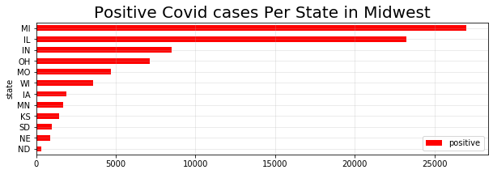

```python
#Plot Positives cases in Midwest
state_and_positive = mw_covid_df[["state","positive"]]
#Drop Nan values
state_and_positive=state_and_positive.dropna()
#Set the index to be "State" so they will be used as labels
state_and_positive = state_and_positive.set_index("state").sort_values('positive')

# Use DataFrame.plot() in order to create a bar chart of the data
state_and_positive.plot(kind="barh", color="red",figsize=(10,3))

# Set a title for the chart
plt.title("Positive Covid cases Per State in Midwest",fontsize=20)
plt.grid(alpha=0.3)
plt.show()
plt.tight_layout()
plt.savefig("fig1.png")
```

# Negative cases in Midwest states

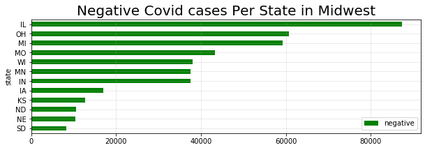

```python
#Plot Negatives cases in Midwest
state_and_negative = mw_covid_df[["state","negative"]]
#Drop Nan values
state_and_negative=state_and_negative.dropna()
#Set the index to be "State" so they will be used as labels
state_and_negative = state_and_negative.set_index("state").sort_values('negative')

# Use DataFrame.plot() in order to create a bar chart of the data
state_and_negative.plot(kind="barh", color="green",figsize=(10,3))

# Set a title for the chart
plt.title("Negative Covid cases Per State in Midwest",fontsize=20)
plt.grid(alpha=0.3)
plt.show()
plt.tight_layout()
plt.savefig("fig2.png")
```

# Deaths due to Covid 19 in Midwest states

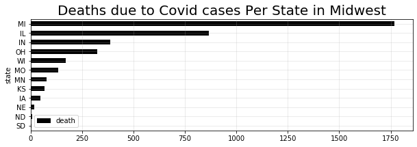

```python
#Plot Deaths in Midwest
state_and_death = mw_covid_df[["state","death"]]
#Drop Nan values
state_and_death=state_and_death.dropna()
#Set the index to be "State" so they will be used as labels
state_and_death = state_and_death.set_index("state").sort_values('death')

# Use DataFrame.plot() in order to create a bar chart of the data
state_and_death.plot(kind="barh",color ="black",figsize=(10,3))

# Set a title for the chart
plt.title("Deaths due to Covid cases Per State in Midwest",fontsize=20)
plt.grid(alpha=0.3)
plt.show()
plt.tight_layout()
plt.savefig("fig3.png")
```

# Analysis of Census data for Poverty count

```python
# Run Census Search to retrieve data on all states
# Note the addition of "B23025_005E" for unemployment count
census_data = c.acs5.get(("NAME", "B19013_001E", "B01003_001E", "B01002_001E",
                          "B19301_001E",
                          "B17001_002E",
                          "B23025_005E"), {'for': 'state:*'})

# Convert to DataFrame
census_pd = pd.DataFrame(census_data)

# Column Reordering
census_pd = census_pd.rename(columns={"B01003_001E": "Population",
                                      "B01002_001E": "Median Age",
                                      "B19013_001E": "Household Income",
                                      "B19301_001E": "Per Capita Income",
                                      "B17001_002E": "Poverty Count",
                                      "B23025_005E": "Unemployment Count",
                                      "NAME": "Name", "state": "State"})

# Add in Poverty Rate (Poverty Count / Population)
#census_pd["Poverty Rate"] = 100 * census_pd["Poverty Count"].astype(int) / census_pd["Population"].astype(int)

# Add in Employment Rate (Employment Count / Population)
#census_pd["Unemployment Rate"] = 100 * \
#    census_pd["Unemployment Count"].astype(int) / census_pd["Population"].astype(int)

# Final DataFrame
census_pd = census_pd[["State", "Name", "Population", "Median Age", "Household Income",
                       "Per Capita Income", "Poverty Count"]]
census_pd = census_pd.drop('State', 1)
census_pd.rename({'Name': 'state'}, axis=1, inplace=True)
#Create a list of the mid west states
mw2_state_list = ['Illinois', 'North Dakota','South Dakota','Nebraska','Kansas','Minnesota','Iowa','Missouri','Wisconsin','Michigan',
                  'Indiana','Ohio']

# Slice the original dataframe using the list of mid west states
census_pd= census_pd[census_pd['state'].isin(mw2_state_list)]
census_pd['state']=census_pd['state'].replace({'North Dakota':'ND','South Dakota':'SD','Nebraska':'NE','Kansas':'KS','Missouri':'MO','Iowa':'IA',
                           'Minnesota':'MN','Wisconsin':'WI','Michigan':'MI','Illinois':'IL','Indiana':'IN','Ohio':'OH'})
census_pd2 =census_pd.sort_values('Poverty Count',ascending=False)
census_pd2.style.background_gradient(cmap='Reds',subset=["Population"])\
                        .background_gradient(cmap='Blues',subset=["Median Age"])\
                        .background_gradient(cmap='Greens',subset=["Household Income"])\
                        .background_gradient(cmap='Oranges',subset=["Per Capita Income"])\
                        .background_gradient(cmap='YlOrBr',subset=["Poverty Count"])
```

|  | state | Population | Median Age | Household Income | Per Capita Income | Poverty Count |
| --- | --- | --- | --- | --- | --- | --- |
| 35 | OH | 1.15496e+07 | 39 | 48308 | 26046 | 1.77385e+06 |
| 13 | IL | 1.28486e+07 | 36.8 | 56797 | 29666 | 1.77233e+06 |
| 22 | MI | 9.8861e+06 | 39.1 | 48411 | 25681 | 1.62598e+06 |
| 14 | IN | 6.51486e+06 | 37.1 | 48248 | 24635 | 969881 |
| 25 | MO | 6.00718e+06 | 38 | 47380 | 25649 | 900929 |
| 49 | WI | 5.70687e+06 | 38.7 | 52413 | 27523 | 723730 |
| 23 | MN | 5.34774e+06 | 37.6 | 59836 | 30913 | 598391 |
| 16 | KS | 2.86811e+06 | 36 | 51332 | 26929 | 382820 |
| 15 | IA | 3.06255e+06 | 38.1 | 51843 | 27027 | 367414 |
| 27 | NE | 1.84162e+06 | 36.3 | 51672 | 26899 | 228789 |
| 41 | SD | 825198 | 36.9 | 49495 | 25740 | 112086 |
| 34 | ND | 689781 | 36.4 | 53741 | 29732 | 79433 |

# Merge data sets to analyse Covid information and Census data

```python
# Merge the datasets using the sate columns
census_data = pd.merge(mw_covid_df,census_pd, how="left", on="state")

census_data=census_data.dropna()
census_data =census_data.drop('index', 1)
census_data
```

|  | state | positive | negative | death | totalTestResults | Mortality Rate (per 100) | Positive Rate (per 100) | Population | Median Age | Household Income | Per Capita Income | Poverty Count |
| --- | --- | --- | --- | --- | --- | --- | --- | --- | --- | --- | --- | --- |
| 0 | IA | 1899.0 | 16986.0 | 49.0 | 18885.0 | 2.58 | 10.06 | 3062553.0 | 38.1 | 51843.0 | 27027.0 | 367414.0 |
| 1 | IL | 23247.0 | 87369.0 | 868.0 | 110616.0 | 3.73 | 21.02 | 12848554.0 | 36.8 | 56797.0 | 29666.0 | 1772333.0 |
| 2 | IN | 8527.0 | 37490.0 | 388.0 | 46017.0 | 4.55 | 18.53 | 6514861.0 | 37.1 | 48248.0 | 24635.0 | 969881.0 |
| 3 | KS | 1426.0 | 12721.0 | 69.0 | 14147.0 | 4.84 | 10.08 | 2868107.0 | 36.0 | 51332.0 | 26929.0 | 382820.0 |
| 4 | MI | 27001.0 | 59225.0 | 1768.0 | 86226.0 | 6.55 | 31.31 | 9886095.0 | 39.1 | 48411.0 | 25681.0 | 1625982.0 |
| 5 | MN | 1695.0 | 37546.0 | 79.0 | 39241.0 | 4.66 | 4.32 | 5347740.0 | 37.6 | 59836.0 | 30913.0 | 598391.0 |
| 6 | MO | 4686.0 | 43292.0 | 133.0 | 47978.0 | 2.84 | 9.77 | 6007182.0 | 38.0 | 47380.0 | 25649.0 | 900929.0 |
| 7 | ND | 341.0 | 10575.0 | 9.0 | 10916.0 | 2.64 | 3.12 | 689781.0 | 36.4 | 53741.0 | 29732.0 | 79433.0 |
| 8 | NE | 871.0 | 10486.0 | 18.0 | 11357.0 | 2.07 | 7.67 | 1841625.0 | 36.3 | 51672.0 | 26899.0 | 228789.0 |
| 9 | OH | 7153.0 | 60721.0 | 324.0 | 67874.0 | 4.53 | 10.54 | 11549590.0 | 39.0 | 48308.0 | 26046.0 | 1773853.0 |
| 10 | SD | 988.0 | 8308.0 | 6.0 | 9296.0 | 0.61 | 10.63 | 825198.0 | 36.9 | 49495.0 | 25740.0 | 112086.0 |
| 11 | WI | 3555.0 | 37997.0 | 170.0 | 41552.0 | 4.78 | 8.56 | 5706871.0 | 38.7 | 52413.0 | 27523.0 | 723730.0 |

# Analysis of the Death Rate and Poverty count via Graphs

Comparing the Death rate vs Poverty count in Midwest, we can look at the correlation and see that it is moderately strong. Mortality rate was higher in most areas of higher poverty

```
The line equation is y = 0.0x + 2.45
R squared: 0.37739653456156547
P value:0.033559695834120856
The correlation coefficient between Poverty count and Mortality Rate is 0.61
```

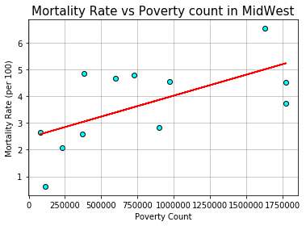

```python
#Plot Death rate vs poverty count in Midwest

## Convert to floats and store Mortality Rate and Poverty Count as x and y values
y_values = census_data['Mortality Rate (per 100)'].astype('float')
x_values = census_data['Poverty Count'].astype('float')

# Run linear regression
(slope, intercept, rvalue, pvalue, stderr) = linregress(x_values, y_values)
regress_values = x_values * slope + intercept
line_eq = "y = " + str(round(slope,2)) + "x + " + str(round(intercept,2))
print(f"The line equation is {line_eq}")

# Plot scatter plot
plt.grid(color='grey', linestyle='-',linewidth=0.55,alpha=0.75)
plt.scatter(x_values,y_values,marker = "o", facecolor = "cyan", edgecolor="black")

# Plot regression line
plt.plot(x_values,regress_values,"r-")
#plt.annotate(line_eq,(3,10),fontsize=15,color="red")

# Label plot
plt.ylabel('Mortality Rate (per 100)')
plt.xlabel('Poverty Count')
plt.title("Mortality Rate vs Poverty count in MidWest",fontsize=15)
# Print r square value
print(f"R squared: {rvalue**2}")
print(f"P value:{pvalue}")

# Calculate the correlation coefficient between Poverty count and Mortality Rate
print(f"The correlation coefficient between Poverty count and Mortality Rate is {round(st.pearsonr(x_values,y_values)[0],2)}")

# Show plot
plt.show()
plt.savefig("fig4.png")
```

# Analysis of the Positive Rate and poverty count via Graphs

# Comparing the Positive rate vs Poverty count in Midwest, we can look at the correlation and see that it is quite strong.

```
The line equation is y = 0.0x + 5.28
R squared: 0.47422009957530353
P value:0.013270308499938016
The correlation coefficient between Poverty count and Positive Rate is 0.69
```

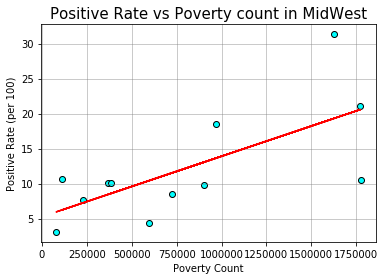

```python
#Plot Positive rate vs poverty count in Midwest

## Convert to floats and store Mortality Rate and Poverty Count as x and y values
y_values = census_data['Positive Rate (per 100)'].astype('float')
x_values = census_data['Poverty Count'].astype('float')

# Run linear regression
(slope, intercept, rvalue, pvalue, stderr) = linregress(x_values, y_values)
regress_values = x_values * slope + intercept
line_eq = "y = " + str(round(slope,2)) + "x + " + str(round(intercept,2))
print(f"The line equation is {line_eq}")

# Plot scatter plot
plt.grid(color='grey', linestyle='-',linewidth=0.55,alpha=0.75)
plt.scatter(x_values,y_values,marker = "o", facecolor = "cyan", edgecolor="black")


#plt.scatter(x_values, weather_df["Max Temp"], marker = "o", facecolor = "cyan", edgecolor="black")
# Plot regression line
plt.plot(x_values,regress_values,"r-")
#plt.annotate(line_eq,(13,80000),fontsize=15,color="red")

# Label plot
plt.ylabel('Positive Rate (per 100)')
plt.xlabel('Poverty Count')
plt.title("Positive Rate vs Poverty count in MidWest",fontsize=15)
# Print r square value
print(f"R squared: {rvalue**2}")
print(f"P value:{pvalue}")

# Calculate the correlation coefficient between Poverty count and Positive Rate
print(f"The correlation coefficient between Poverty count and Positive Rate is {round(st.pearsonr(x_values,y_values)[0],2)}")


# Show plot
plt.show()
plt.savefig("fig5.png")
```

# Analysis of the Positive Rate and Household Income via Graphs

Here we have negative correlation.We can say that in lower income households the positive rate seems higher, but not statistically significant.

```
The line equation is y = -0.0x + 47.13
R squared: 0.10428969632696994
P value:0.30590901758439987
The correlation coefficient between Household Income and Positive Rate is -0.32
```

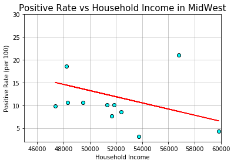

```python
#Plot Positive rate vs poverty count in Midwest

## Convert to floats and store Mortality Rate and Poverty Count as x and y values

x_values = census_data['Household Income'].astype('float')
y_values = census_data['Positive Rate (per 100)'].astype('float')



# Run linear regression
(slope, intercept, rvalue, pvalue, stderr) = linregress(x_values, y_values)
regress_values = x_values * slope + intercept
line_eq = "y = " + str(round(slope,2)) + "x + " + str(round(intercept,2))
print(f"The line equation is {line_eq}")
# Plot scatter plot
plt.grid(color='grey', linestyle='-',linewidth=0.55,alpha=0.75)
plt.scatter(x_values,y_values,marker = "o", facecolor = "cyan", edgecolor="black")

# Plot regression line
plt.plot(x_values,regress_values,"r-")
#plt.annotate(line_eq,(25,40000),fontsize=11,color="red")

plt.xlim([45000, 60000])
plt.ylim([2,30])
figsize=(6,3)
# Label plot
plt.ylabel('Positive Rate (per 100)')
plt.xlabel('Household Income')
plt.title("Positive Rate vs Household Income in MidWest",fontsize=15)
# Print r square value
print(f"R squared: {rvalue**2}")
print(f"P value:{pvalue}")

# Calculate the correlation coefficient between Household Income and Positive Rate
print(f"The correlation coefficient between Household Income and Positive Rate is {round(st.pearsonr(x_values,y_values)[0],2)}")

# Show plot
plt.show()
plt.savefig("fig6.png")
```

# Analysis of Spread and Death due to COVID 19 in the Midwest

The number of deaths in the midwest went up in the first 2 weeks of April but after that the trend has been the same. The total number of recovered cases is far less than the positive cases.

```python
# Read in the csv file for Covid Data and Create dataframe
covid_timeline_df = pd.read_csv('daily (1).csv')
covid_timeline_df=covid_timeline_df.drop([ "pending","hospitalizedCurrently","hospitalizedCumulative","inIcuCurrently",
                                         "inIcuCumulative","onVentilatorCurrently","onVentilatorCumulative","hash",
                                        "hospitalized","total" ,"posNeg","fips","dateChecked"], axis=1)

,""#Create a list of the mid west states
mw_state_list = ['IL', 'ND','SD','NE','KS','MO','IA','MN','WI','MI','IN','OH']

# Slice the original dataframe using the list of mid west states
mw_covid_timeline_df= covid_timeline_df[covid_timeline_df['state'].isin(mw_state_list)]
mw_covid_timeline_df.date =mw_covid_timeline_df.date.astype(str)
mw_covid_timeline_df['date'] =pd.to_datetime(mw_covid_timeline_df['date'])
mw_covid_timeline_df=mw_covid_timeline_df.dropna()
mw_covid_timeline_df
```

|  | date | state | positive | negative | recovered | death | totalTestResults | deathIncrease | hospitalizedIncrease | negativeIncrease | positiveIncrease | totalTestResultsIncrease |
| --- | --- | --- | --- | --- | --- | --- | --- | --- | --- | --- | --- | --- |
| 14 | 2020-04-20 | IA | 3159.0 | 22661.0 | 1235.0 | 79.0 | 25820.0 | 4.0 | 0.0 | 1013.0 | 257.0 | 1270.0 |
| 24 | 2020-04-20 | MI | 32000.0 | 81798.0 | 3237.0 | 2468.0 | 113798.0 | 77.0 | 0.0 | 3561.0 | 576.0 | 4137.0 |
| 25 | 2020-04-20 | MN | 2470.0 | 44380.0 | 1202.0 | 143.0 | 46850.0 | 9.0 | 28.0 | 1020.0 | 114.0 | 1134.0 |
| 31 | 2020-04-20 | ND | 627.0 | 14120.0 | 189.0 | 13.0 | 14747.0 | 3.0 | 2.0 | 1075.0 | 42.0 | 1117.0 |
| 45 | 2020-04-20 | SD | 1685.0 | 10641.0 | 709.0 | 7.0 | 12326.0 | 0.0 | 13.0 | 214.0 | 50.0 | 264.0 |
| ... | ... | ... | ... | ... | ... | ... | ... | ... | ... | ... | ... | ... |
| 1375 | 2020-03-27 | ND | 65.0 | 2427.0 | 15.0 | 0.0 | 2492.0 | 0.0 | 3.0 | 388.0 | 13.0 | 401.0 |
| 1389 | 2020-03-27 | SD | 58.0 | 2387.0 | 21.0 | 1.0 | 2445.0 | 0.0 | 0.0 | 414.0 | 12.0 | 426.0 |
| 1414 | 2020-03-26 | IA | 179.0 | 2578.0 | 15.0 | 1.0 | 2757.0 | 0.0 | 10.0 | 0.0 | 34.0 | 34.0 |
| 1445 | 2020-03-26 | SD | 46.0 | 1973.0 | 16.0 | 1.0 | 2019.0 | 0.0 | 0.0 | 1154.0 | 5.0 | 1159.0 |
| 1481 | 2020-03-25 | MN | 287.0 | 11188.0 | 122.0 | 1.0 | 11475.0 | 0.0 | 14.0 | 5638.0 | 25.0 | 5663.0 |

116 rows × 12 columns

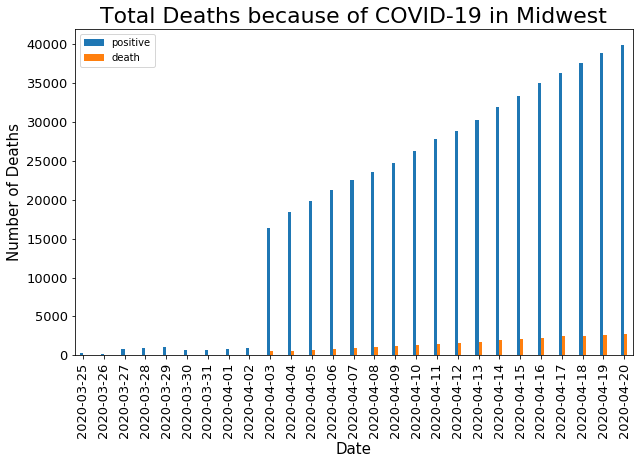

```python
df = mw_covid_timeline_df.groupby(['date'])['positive','death'].sum()

ax = df.plot(kind='bar', figsize=(10,6),  fontsize=13,width=0.3);
x_labels = df.index.strftime('%Y-%m-%d')
ax.set_xticklabels(x_labels)
ax.set_alpha(0.8)
ax.set_title("Total Deaths because of COVID-19 in Midwest", fontsize=22)
ax.set_xlabel("Date", fontsize=15);
ax.set_ylabel("Number of Deaths", fontsize=15);
plt.show()
plt.savefig("fig7.png")
```

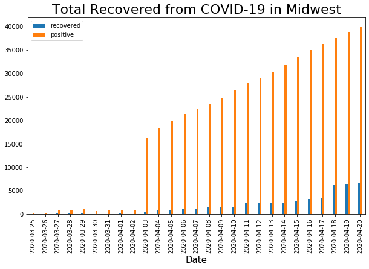

```python
df2 = mw_covid_timeline_df.groupby(['date'])['recovered','positive'].sum()

ax = df2.plot(kind='bar', figsize=(10,6),width=0.3);
x_labels = df.index.strftime('%Y-%m-%d')
ax.set_xticklabels(x_labels)
ax.set_alpha(0.8)
ax.set_title("Total Recovered from COVID-19 in Midwest", fontsize=22)
ax.set_xlabel("Date", fontsize=15);

plt.show()
plt.savefig("fig8.png")
```

# Census poverty data from counties in midwest.

Since the sample size at states level is comparatively small, we decided to study the data at county level to get more correct information.

```python
# Request census data through API
census_county_data = c.acs5.state_county(("NAME", "B19013_001E", "B01003_001E", "B01002_001E",
                          "B19301_001E",
                          "B17001_002E"), Census.ALL, Census.ALL)
census_county_df = pd.DataFrame(census_county_data)
census_county_df.head()
```

|  | NAME | B19013_001E | B01003_001E | B01002_001E | B19301_001E | B17001_002E | state | county |
| --- | --- | --- | --- | --- | --- | --- | --- | --- |
| 0 | Las Marías Municipio, Puerto Rico | 15779.0 | 9699.0 | 37.3 | 7000.0 | 5563.0 | 72 | 083 |
| 1 | Añasco Municipio, Puerto Rico | 16568.0 | 29086.0 | 39.4 | 7892.0 | 14599.0 | 72 | 011 |
| 2 | San Sebastián Municipio, Puerto Rico | 14463.0 | 41798.0 | 39.7 | 7174.0 | 22961.0 | 72 | 131 |
| 3 | Bayamón Municipio, Puerto Rico | 24374.0 | 204725.0 | 38.6 | 12648.0 | 70734.0 | 72 | 021 |
| 4 | Cataño Municipio, Puerto Rico | 18977.0 | 27669.0 | 35.6 | 10567.0 | 13563.0 | 72 | 033 |

```python
#Clean up the data
census_county_df = census_county_df.drop([ "state","county"],axis=1)
census_county_df.head()
```

|  | NAME | B19013_001E | B01003_001E | B01002_001E | B19301_001E | B17001_002E |
| --- | --- | --- | --- | --- | --- | --- |
| 0 | Las Marías Municipio, Puerto Rico | 15779.0 | 9699.0 | 37.3 | 7000.0 | 5563.0 |
| 1 | Añasco Municipio, Puerto Rico | 16568.0 | 29086.0 | 39.4 | 7892.0 | 14599.0 |
| 2 | San Sebastián Municipio, Puerto Rico | 14463.0 | 41798.0 | 39.7 | 7174.0 | 22961.0 |
| 3 | Bayamón Municipio, Puerto Rico | 24374.0 | 204725.0 | 38.6 | 12648.0 | 70734.0 |
| 4 | Cataño Municipio, Puerto Rico | 18977.0 | 27669.0 | 35.6 | 10567.0 | 13563.0 |

```python
census_county_df[['county','state']] = census_county_df['NAME'].str.split(", ", expand=True)
census_county_df.head()
```

|  | NAME | B19013_001E | B01003_001E | B01002_001E | B19301_001E | B17001_002E | county | state |
| --- | --- | --- | --- | --- | --- | --- | --- | --- |
| 0 | Las Marías Municipio, Puerto Rico | 15779.0 | 9699.0 | 37.3 | 7000.0 | 5563.0 | Las Marías Municipio | Puerto Rico |
| 1 | Añasco Municipio, Puerto Rico | 16568.0 | 29086.0 | 39.4 | 7892.0 | 14599.0 | Añasco Municipio | Puerto Rico |
| 2 | San Sebastián Municipio, Puerto Rico | 14463.0 | 41798.0 | 39.7 | 7174.0 | 22961.0 | San Sebastián Municipio | Puerto Rico |
| 3 | Bayamón Municipio, Puerto Rico | 24374.0 | 204725.0 | 38.6 | 12648.0 | 70734.0 | Bayamón Municipio | Puerto Rico |
| 4 | Cataño Municipio, Puerto Rico | 18977.0 | 27669.0 | 35.6 | 10567.0 | 13563.0 | Cataño Municipio | Puerto Rico |

```python
census_county_df['county'] = census_county_df['county'].str.replace(" County", "")
census_county_df
```

|  | NAME | B19013_001E | B01003_001E | B01002_001E | B19301_001E | B17001_002E | county | state |
| --- | --- | --- | --- | --- | --- | --- | --- | --- |
| 0 | Las Marías Municipio, Puerto Rico | 15779.0 | 9699.0 | 37.3 | 7000.0 | 5563.0 | Las Marías Municipio | Puerto Rico |
| 1 | Añasco Municipio, Puerto Rico | 16568.0 | 29086.0 | 39.4 | 7892.0 | 14599.0 | Añasco Municipio | Puerto Rico |
| 2 | San Sebastián Municipio, Puerto Rico | 14463.0 | 41798.0 | 39.7 | 7174.0 | 22961.0 | San Sebastián Municipio | Puerto Rico |
| 3 | Bayamón Municipio, Puerto Rico | 24374.0 | 204725.0 | 38.6 | 12648.0 | 70734.0 | Bayamón Municipio | Puerto Rico |
| 4 | Cataño Municipio, Puerto Rico | 18977.0 | 27669.0 | 35.6 | 10567.0 | 13563.0 | Cataño Municipio | Puerto Rico |
| ... | ... | ... | ... | ... | ... | ... | ... | ... |
| 3216 | Monroe County, West Virginia | 41234.0 | 13512.0 | 45.8 | 20294.0 | 1824.0 | Monroe | West Virginia |
| 3217 | Morgan County, West Virginia | 36046.0 | 17502.0 | 45.5 | 22312.0 | 2651.0 | Morgan | West Virginia |
| 3218 | Nicholas County, West Virginia | 40064.0 | 26168.0 | 44.1 | 23209.0 | 4957.0 | Nicholas | West Virginia |
| 3219 | Ohio County, West Virginia | 41025.0 | 44156.0 | 43.3 | 26135.0 | 6453.0 | Ohio | West Virginia |
| 3220 | Pendleton County, West Virginia | 34175.0 | 7603.0 | 48.3 | 21253.0 | 1402.0 | Pendleton | West Virginia |

3221 rows × 8 columns

```python
census_county_df = census_county_df.drop(["NAME"],axis=1)
census_county_df.head()
```

|  | B19013_001E | B01003_001E | B01002_001E | B19301_001E | B17001_002E | county | state |
| --- | --- | --- | --- | --- | --- | --- | --- |
| 0 | 15779.0 | 9699.0 | 37.3 | 7000.0 | 5563.0 | Las Marías Municipio | Puerto Rico |
| 1 | 16568.0 | 29086.0 | 39.4 | 7892.0 | 14599.0 | Añasco Municipio | Puerto Rico |
| 2 | 14463.0 | 41798.0 | 39.7 | 7174.0 | 22961.0 | San Sebastián Municipio | Puerto Rico |
| 3 | 24374.0 | 204725.0 | 38.6 | 12648.0 | 70734.0 | Bayamón Municipio | Puerto Rico |
| 4 | 18977.0 | 27669.0 | 35.6 | 10567.0 | 13563.0 | Cataño Municipio | Puerto Rico |

```python
census_county_df = census_county_df[['state','county','B19013_001E','B01003_001E','B01002_001E','B19301_001E','B17001_002E']]
census_county_df.head()
```

|  | state | county | B19013_001E | B01003_001E | B01002_001E | B19301_001E | B17001_002E |
| --- | --- | --- | --- | --- | --- | --- | --- |
| 0 | Puerto Rico | Las Marías Municipio | 15779.0 | 9699.0 | 37.3 | 7000.0 | 5563.0 |
| 1 | Puerto Rico | Añasco Municipio | 16568.0 | 29086.0 | 39.4 | 7892.0 | 14599.0 |
| 2 | Puerto Rico | San Sebastián Municipio | 14463.0 | 41798.0 | 39.7 | 7174.0 | 22961.0 |
| 3 | Puerto Rico | Bayamón Municipio | 24374.0 | 204725.0 | 38.6 | 12648.0 | 70734.0 |
| 4 | Puerto Rico | Cataño Municipio | 18977.0 | 27669.0 | 35.6 | 10567.0 | 13563.0 |

```python
census_county_df = census_county_df.rename(columns={"B01003_001E": "Population",
                                      "B01002_001E": "Median Age",
                                      "B19013_001E": "Household Income",
                                      "B19301_001E": "Per Capita Income",
                                      "B17001_002E": "Poverty Count"})
census_county_df.head()
```

|  | state | county | Household Income | Population | Median Age | Per Capita Income | Poverty Count |
| --- | --- | --- | --- | --- | --- | --- | --- |
| 0 | Puerto Rico | Las Marías Municipio | 15779.0 | 9699.0 | 37.3 | 7000.0 | 5563.0 |
| 1 | Puerto Rico | Añasco Municipio | 16568.0 | 29086.0 | 39.4 | 7892.0 | 14599.0 |
| 2 | Puerto Rico | San Sebastián Municipio | 14463.0 | 41798.0 | 39.7 | 7174.0 | 22961.0 |
| 3 | Puerto Rico | Bayamón Municipio | 24374.0 | 204725.0 | 38.6 | 12648.0 | 70734.0 |
| 4 | Puerto Rico | Cataño Municipio | 18977.0 | 27669.0 | 35.6 | 10567.0 | 13563.0 |

# COVID-19 Data at County Level

```python
#Import covid data
covid_county_df = pd.read_csv('us-counties.csv')
covid_county_df.head()
```

|  | date | county | state | fips | cases | deaths |
| --- | --- | --- | --- | --- | --- | --- |
| 0 | 1/21/20 | Snohomish | Washington | 53061.0 | 1 | 0 |
| 1 | 1/22/20 | Snohomish | Washington | 53061.0 | 1 | 0 |
| 2 | 1/23/20 | Snohomish | Washington | 53061.0 | 1 | 0 |
| 3 | 1/24/20 | Cook | Illinois | 17031.0 | 1 | 0 |
| 4 | 1/24/20 | Snohomish | Washington | 53061.0 | 1 | 0 |

```python
most_recent_covid_df = covid_county_df.loc[covid_county_df["date"]=="4/13/20"]
most_recent_covid_df.head()
```

|  | date | county | state | fips | cases | deaths |
| --- | --- | --- | --- | --- | --- | --- |
| 53848 | 4/13/20 | Autauga | Alabama | 1001.0 | 19 | 1 |
| 53849 | 4/13/20 | Baldwin | Alabama | 1003.0 | 78 | 1 |
| 53850 | 4/13/20 | Barbour | Alabama | 1005.0 | 10 | 0 |
| 53851 | 4/13/20 | Bibb | Alabama | 1007.0 | 17 | 0 |
| 53852 | 4/13/20 | Blount | Alabama | 1009.0 | 15 | 0 |

From here, we only look at data as of Apr 13 2020.

```python
most_recent_covid_df = most_recent_covid_df.drop(["date"],axis=1)
most_recent_covid_df.head()
```

|  | county | state | fips | cases | deaths |
| --- | --- | --- | --- | --- | --- |
| 53848 | Autauga | Alabama | 1001.0 | 19 | 1 |
| 53849 | Baldwin | Alabama | 1003.0 | 78 | 1 |
| 53850 | Barbour | Alabama | 1005.0 | 10 | 0 |
| 53851 | Bibb | Alabama | 1007.0 | 17 | 0 |
| 53852 | Blount | Alabama | 1009.0 | 15 | 0 |

```python
#Create a list of the mid west states
mw_state_list = ["Illinois", 'Indiana','Iowa','Kansas','Michigan','Minnesota','Missouri','Nebraska','North Dakota','Ohio','South Dakota','Wisconsin']
mw_state_list
```

```
['Illinois',
 'Indiana',
 'Iowa',
 'Kansas',
 'Michigan',
 'Minnesota',
 'Missouri',
 'Nebraska',
 'North Dakota',
 'Ohio',
 'South Dakota',
 'Wisconsin']
```

```python
# Select midwest states covid data
mw_covid_county_df = most_recent_covid_df[most_recent_covid_df['state'].isin(mw_state_list)]
mw_covid_county_df = mw_covid_county_df[['state','county','fips','cases','deaths']]
mw_covid_county_df.head()
```

|  | state | county | fips | cases | deaths |
| --- | --- | --- | --- | --- | --- |
| 54402 | Illinois | Adams | 17001.0 | 26 | 0 |
| 54403 | Illinois | Bond | 17005.0 | 4 | 0 |
| 54404 | Illinois | Boone | 17007.0 | 13 | 1 |
| 54405 | Illinois | Bureau | 17011.0 | 6 | 0 |
| 54406 | Illinois | Calhoun | 17013.0 | 1 | 0 |

```python
# Select midwest states census data
mw_census_county_df= census_county_df[census_county_df['state'].isin(mw_state_list)]
mw_census_county_df.head()
```

|  | state | county | Household Income | Population | Median Age | Per Capita Income | Poverty Count |
| --- | --- | --- | --- | --- | --- | --- | --- |
| 622 | Michigan | Alcona | 37189.0 | 10785.0 | 55.8 | 22719.0 | 1612.0 |
| 623 | Michigan | Alger | 37586.0 | 9497.0 | 48.1 | 19717.0 | 1257.0 |
| 624 | Michigan | Allegan | 52061.0 | 111742.0 | 39.6 | 24140.0 | 14933.0 |
| 625 | Michigan | Alpena | 38016.0 | 29399.0 | 46.4 | 21948.0 | 4999.0 |
| 626 | Michigan | Antrim | 45362.0 | 23504.0 | 48.3 | 24370.0 | 3570.0 |

```python
# Merge covid and census data
mw_census_covid_df = mw_covid_county_df.merge(mw_census_county_df, how='inner', left_on=["state","county"], right_on=["state","county"] )
mw_census_covid_df.head()
```

|  | state | county | fips | cases | deaths | Household Income | Population | Median Age | Per Capita Income | Poverty Count |
| --- | --- | --- | --- | --- | --- | --- | --- | --- | --- | --- |
| 0 | Illinois | Adams | 17001.0 | 26 | 0 | 45073.0 | 67152.0 | 40.6 | 24217.0 | 9374.0 |
| 1 | Illinois | Bond | 17005.0 | 4 | 0 | 48163.0 | 17665.0 | 40.0 | 23195.0 | 2462.0 |
| 2 | Illinois | Boone | 17007.0 | 13 | 1 | 60893.0 | 54068.0 | 37.3 | 25888.0 | 6055.0 |
| 3 | Illinois | Bureau | 17011.0 | 6 | 0 | 48977.0 | 34594.0 | 43.0 | 26705.0 | 3955.0 |
| 4 | Illinois | Calhoun | 17013.0 | 1 | 0 | 50436.0 | 5062.0 | 45.1 | 26924.0 | 593.0 |

```python
# Calculate poverty rate, positive covid rate, mortality rate for each county in midwest.
mw_census_covid_df["Poverty Rate"] = mw_census_covid_df["Poverty Count"].astype(int)/mw_census_covid_df["Population"].astype(int)
mw_census_covid_df["Positive Rate"] = mw_census_covid_df["cases"].astype(int)/mw_census_covid_df["Population"].astype(int)
mw_census_covid_df["Mortality Rate"] = mw_census_covid_df["deaths"].astype(int)/mw_census_covid_df["cases"].astype(int)

mw_census_covid_df.head()
```

|  | state | county | fips | cases | deaths | Household Income | Population | Median Age | Per Capita Income | Poverty Count | Poverty Rate | Positive Rate | Mortality Rate |
| --- | --- | --- | --- | --- | --- | --- | --- | --- | --- | --- | --- | --- | --- |
| 0 | Illinois | Adams | 17001.0 | 26 | 0 | 45073.0 | 67152.0 | 40.6 | 24217.0 | 9374.0 | 0.139594 | 0.000387 | 0.000000 |
| 1 | Illinois | Bond | 17005.0 | 4 | 0 | 48163.0 | 17665.0 | 40.0 | 23195.0 | 2462.0 | 0.139372 | 0.000226 | 0.000000 |
| 2 | Illinois | Boone | 17007.0 | 13 | 1 | 60893.0 | 54068.0 | 37.3 | 25888.0 | 6055.0 | 0.111989 | 0.000240 | 0.076923 |
| 3 | Illinois | Bureau | 17011.0 | 6 | 0 | 48977.0 | 34594.0 | 43.0 | 26705.0 | 3955.0 | 0.114326 | 0.000173 | 0.000000 |
| 4 | Illinois | Calhoun | 17013.0 | 1 | 0 | 50436.0 | 5062.0 | 45.1 | 26924.0 | 593.0 | 0.117147 | 0.000198 | 0.000000 |

# Graph average poverty rate

```python
# Calculate the average poverty rate by state
mw_state_poverty_df = mw_census_covid_df.groupby('state')
mw_state_poverty_df = pd.DataFrame(mw_state_poverty_df['Poverty Rate'].mean().sort_values())
mw_state_poverty_df
```

| state | Poverty Rate |
| --- | --- |
| Nebraska | 0.111387 |
| Iowa | 0.111926 |
| Minnesota | 0.113557 |
| Wisconsin | 0.122486 |
| North Dakota | 0.125061 |
| Illinois | 0.129577 |
| Kansas | 0.132744 |
| Indiana | 0.136391 |
| South Dakota | 0.136659 |
| Ohio | 0.148215 |
| Michigan | 0.164307 |
| Missouri | 0.167134 |

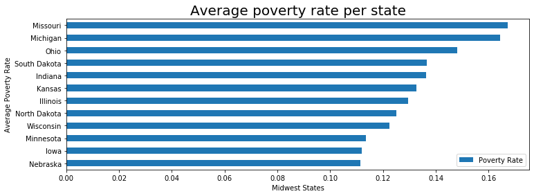

```python
# Bar plot to show average poverty rate per state
state_poverty_bar_chart = mw_state_poverty_df.plot(kind='barh', figsize=(12,4))
state_poverty_bar_chart.set_title("Average poverty rate per state", fontsize=20)
state_poverty_bar_chart.set_xlabel("Midwest States")
state_poverty_bar_chart.set_ylabel("Average Poverty Rate")

plt.savefig('Average poverty rate per state in midwest.png')
plt.show()
```

Missouri, Michigan and Ohio are the highest average poverty rate.

# Poverty rate distribution in midwest

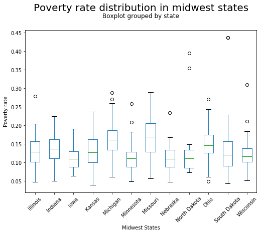

```python
# Box plot to show the distribution of poverty rate in each state
mw_county_poverty_dist = mw_census_covid_df.boxplot(column=['Poverty Rate'], by='state',grid=False, rot=45, fontsize=10, figsize=(8,6))
plt.title("Poverty rate distribution in midwest states", y=1.1, fontsize=20 )
plt.xlabel("Midwest States")
plt.ylabel("Poverty rate")

plt.savefig('Poverty rate distribution in midwest states.png')
plt.show()
```

# Graph positive covid cases in midwest

```python
# Calculate the positive covid case by state
mw_state_covid_df = mw_census_covid_df.groupby('state')
mw_state_positive_df = pd.DataFrame(mw_state_covid_df['cases'].sum().sort_values())
mw_state_positive_df
```

| state | cases |
| --- | --- |
| North Dakota | 331 |
| South Dakota | 867 |
| Nebraska | 870 |
| Kansas | 1385 |
| Minnesota | 1616 |
| Iowa | 1710 |
| Wisconsin | 3428 |
| Missouri | 4059 |
| Ohio | 6975 |
| Indiana | 8236 |
| Illinois | 21963 |
| Michigan | 25021 |

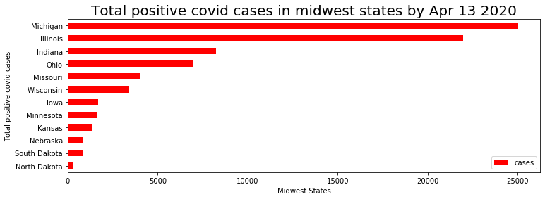

```python
# Bar plot to show positive covid cases per state
state_positive_bar_chart = mw_state_positive_df.plot(kind='barh', color="red", figsize=(12,4))
state_positive_bar_chart.set_title("Total positive covid cases in midwest states by Apr 13 2020",fontsize=20)
state_positive_bar_chart.set_xlabel("Midwest States")
state_positive_bar_chart.set_ylabel("Total positive covid cases")
plt.savefig('Total positive covid cases in midwest states by Apr 13 2020.png')
plt.show()
```

Michigan and Illinois have the most positive covid cases in midwest by Apr 13 2020.

# Positive covid case distribution in midwest

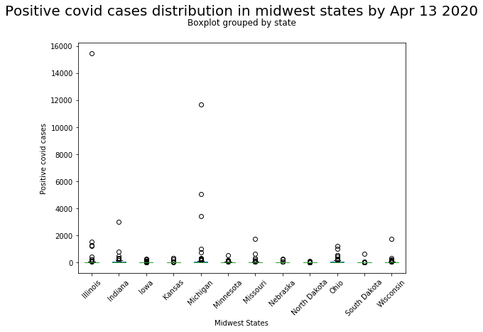

```python
# Box plot to show the distribution of positive covid case in each state
mw_county_covid_dist = mw_census_covid_df.boxplot(column=['cases'], by='state',grid=False, rot=45, fontsize=10,figsize=(8,6))
plt.title("Positive covid cases distribution in midwest states by Apr 13 2020", y=1.1, fontsize=20)
plt.xlabel("Midwest States")
plt.ylabel("Positive covid cases")

plt.savefig('Positive covid cases distribution in midwest states by Apr 13 2020.png')
plt.show()
```

The median of positive covid cases in midwest sates are similar. However, Michigan and Illinois have more extrame outliers than other states.

# Bar plot to show total covid death per state

```python
# Calculate the total covid death by state
mw_state_covid_df = mw_census_covid_df.groupby('state')
mw_state_mortality_df = pd.DataFrame(mw_state_covid_df['deaths'].sum().sort_values())
mw_state_mortality_df
```

| state | deaths |
| --- | --- |
| South Dakota | 6 |
| North Dakota | 9 |
| Nebraska | 19 |
| Iowa | 44 |
| Kansas | 63 |
| Minnesota | 70 |
| Missouri | 129 |
| Wisconsin | 155 |
| Ohio | 274 |
| Indiana | 350 |
| Illinois | 800 |
| Michigan | 1591 |

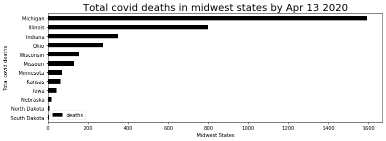

```python
# Bar plot to show covid deaths per state
state_mortality_bar_chart = mw_state_mortality_df.plot(kind='barh', color="black", figsize=(12,4))
state_mortality_bar_chart.set_title("Total covid deaths in midwest states by Apr 13 2020",fontsize=20)
state_mortality_bar_chart.set_xlabel("Midwest States")
state_mortality_bar_chart.set_ylabel("Total covid deaths")
plt.savefig('Total covid deaths in midwest states by Apr 13 2020.png')
plt.show()
```

Michigan and Illinois have the highest covid death counts in midwest.

# Covid deaths distribution in midwest

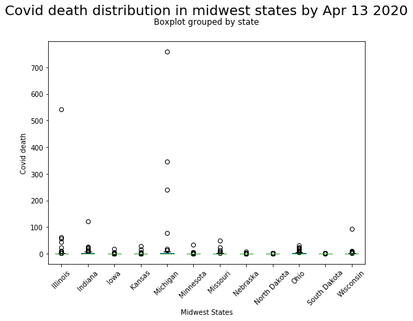

```python
# Box plot to show the distribution of covid deaths in each state
mw_county_covid_death_dist = mw_census_covid_df.boxplot(column=['deaths'], by='state',grid=False, rot=45, fontsize=10,figsize=(8,6))
plt.title("Covid death distribution in midwest states by Apr 13 2020", y=1.1, fontsize=20)
plt.xlabel("Midwest States")
plt.ylabel("Covid death")

plt.savefig('Covid death distribution in midwest states by Apr 13 2020.png')
plt.show()
```

The median of covid death counts in midwest sates are also similar. However, Michigan and Illinois have more extrame outliers than other states.

# Scatter plot to show the correlation between covid positive rate vs poverty rate in midwest

```
The line equation is y = -0.00053x + 0.00056
R squared: 0.0013282926070112924
P value:0.2960466311187357
The correlation coefficient between Poverty rate and Positive COVID Rate is -0.04 in midwest at county level
```

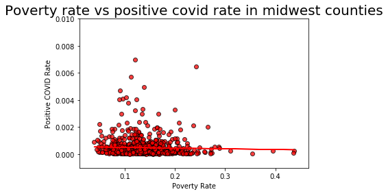

```python
# Scatter plot to show poverty rate and positive covid case in midwest counties
x_values = mw_census_covid_df['Poverty Rate']
y_values = mw_census_covid_df['Positive Rate']

# Run linear regression
(slope, intercept, rvalue, pvalue, stderr) = linregress(x_values, y_values)
regress_values = x_values * slope + intercept
line_eq = "y = " + str(round(slope,5)) + "x + " + str(round(intercept,5))
print(f"The line equation is {line_eq}")

# Plot scatter plot
plt.scatter(x_values,y_values,marker = "o", facecolor = "red", edgecolor="black",alpha=0.75)

# Plot regression line
plt.plot(x_values,regress_values,"r-")
plt.ylim(-0.001,0.01)
plt.title("Poverty rate vs positive covid rate in midwest counties", fontsize=20)
plt.xlabel("Poverty Rate")
plt.ylabel("Positive COVID Rate")
print(f"R squared: {rvalue**2}")
print(f"P value:{pvalue}")
print(f"The correlation coefficient between Poverty rate and Positive COVID Rate is {round(st.pearsonr(x_values,y_values)[0],2)} in midwest at county level")
plt.savefig('Poverty rate vs positive covid rate in midwest counties.png')

plt.show()
```

# Scatter plot to show the correlation between covid death rate vs poverty rate in midwest

```
The line equation is y = 0.09229x + 0.0253
R squared: 0.0018208017604717617
P value:0.2211100190375592
The correlation coefficient between Poverty rate and COVID Mortality Rate is 0.04 in midwest at county level
```

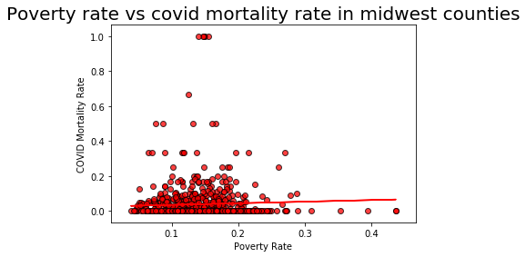

```python
# Scatter plot to show poverty rate and covid mortality rate in midwest counties
x_values = mw_census_covid_df['Poverty Rate']
y_values = mw_census_covid_df['Mortality Rate']

# Run linear regression
(slope, intercept, rvalue, pvalue, stderr) = linregress(x_values, y_values)
regress_values = x_values * slope + intercept
line_eq = "y = " + str(round(slope,5)) + "x + " + str(round(intercept,5))
print(f"The line equation is {line_eq}")

# Plot scatter plot
plt.scatter(x_values,y_values,marker = "o", facecolor = "red", edgecolor="black",alpha=0.75)

# Plot regression line
plt.plot(x_values,regress_values,"r-")
plt.title("Poverty rate vs covid mortality rate in midwest counties", fontsize=20)
plt.xlabel("Poverty Rate")
plt.ylabel("COVID Mortality Rate")
print(f"R squared: {rvalue**2}")
print(f"P value:{pvalue}")
print(f"The correlation coefficient between Poverty rate and COVID Mortality Rate is {round(st.pearsonr(x_values,y_values)[0],2)} in midwest at county level")
plt.savefig('Poverty rate vs covid mortality rate in midwest counties.png')

plt.show()
```

# Scatter plot to show the correlation between covid positive case vs poverty count in midwest

```
The line equation is y = 0.017x + -94.838
R squared: 0.8218215465582823
P value:3.87569998635685e-310
The correlation coefficient between Poverty Count and Positive COVID Case is 0.91 in midwest at county level
```

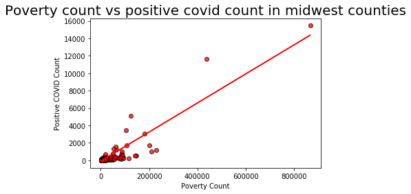

```python
# Scatter plot to show poverty count and positive covid case in midwest counties
x_values = mw_census_covid_df['Poverty Count']
y_values = mw_census_covid_df['cases']

# Run linear regression
(slope, intercept, rvalue, pvalue, stderr) = linregress(x_values, y_values)
regress_values = x_values * slope + intercept
line_eq = "y = " + str(round(slope,3)) + "x + " + str(round(intercept,3))
print(f"The line equation is {line_eq}")

# Plot scatter plot
plt.scatter(x_values,y_values,marker = "o", facecolor = "red", edgecolor="black",alpha=0.75)

# Plot regression line
plt.plot(x_values,regress_values,"r-")
plt.title("Poverty count vs positive covid count in midwest counties",fontsize=20)
plt.xlabel("Poverty Count")
plt.ylabel("Positive COVID Count")

print(f"R squared: {rvalue**2}")
print(f"P value:{pvalue}")
print(f"The correlation coefficient between Poverty Count and Positive COVID Case is {round(st.pearsonr(x_values,y_values)[0],2)} in midwest at county level")

plt.savefig('Poverty count vs positive covid count in midwest counties.png')

plt.show()
```

# #Scatter plot to show the correlation between covid death count vs poverty count in midwest

```
The line equation is y = 0.001x + -3.97
R squared: 0.6319525333471797
P value:1.3495801341736383e-180
The correlation coefficient between Poverty Count and COVID Death is 0.79 in midwest at county level
```

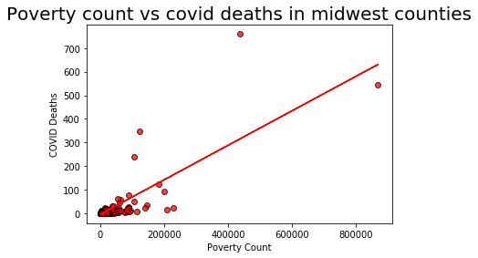

```python
# Scatter plot to show poverty count and covid deaths in midwest counties
x_values = mw_census_covid_df['Poverty Count']
y_values = mw_census_covid_df['deaths']

# Run linear regression
(slope, intercept, rvalue, pvalue, stderr) = linregress(x_values, y_values)
regress_values = x_values * slope + intercept
line_eq = "y = " + str(round(slope,3)) + "x + " + str(round(intercept,3))
print(f"The line equation is {line_eq}")

# Plot scatter plot
plt.scatter(x_values,y_values,marker = "o", facecolor = "red", edgecolor="black",alpha=0.75)

# Plot regression line
plt.plot(x_values,regress_values,"r-")
plt.title("Poverty count vs covid deaths in midwest counties", fontsize=20)
plt.xlabel("Poverty Count")
plt.ylabel("COVID Deaths")

print(f"R squared: {rvalue**2}")
print(f"P value:{pvalue}")
print(f"The correlation coefficient between Poverty Count and COVID Death is {round(st.pearsonr(x_values,y_values)[0],2)} in midwest at county level")


plt.savefig('Poverty count vs covid deaths in midwest counties.png')

plt.show()
```

# Race Data

## Census API Call

```python
# Census API Call
census_county_data = c.acs5.state_county(("NAME", "B01003_001E", "B02001_002E", "B02001_003E", "B02001_004E", "B02001_005E", "B02001_006E", "B02001_007E", "B02001_008E"), Census.ALL, Census.ALL)
census_county_df = pd.DataFrame(census_county_data)
census_county_df.head()
```

|  | NAME | B01003_001E | B02001_002E | B02001_003E | B02001_004E | B02001_005E | B02001_006E | B02001_007E | B02001_008E | state | county |
| --- | --- | --- | --- | --- | --- | --- | --- | --- | --- | --- | --- |
| 0 | Las Marías Municipio, Puerto Rico | 9699.0 | 9372.0 | 158.0 | 23.0 | 0.0 | 0.0 | 112.0 | 34.0 | 72 | 083 |
| 1 | Añasco Municipio, Puerto Rico | 29086.0 | 21607.0 | 869.0 | 0.0 | 21.0 | 0.0 | 4838.0 | 1751.0 | 72 | 011 |
| 2 | San Sebastián Municipio, Puerto Rico | 41798.0 | 38569.0 | 622.0 | 0.0 | 24.0 | 0.0 | 2288.0 | 295.0 | 72 | 131 |
| 3 | Bayamón Municipio, Puerto Rico | 204725.0 | 124341.0 | 16059.0 | 1624.0 | 688.0 | 5.0 | 17664.0 | 44344.0 | 72 | 021 |
| 4 | Cataño Municipio, Puerto Rico | 27669.0 | 18876.0 | 2375.0 | 108.0 | 17.0 | 0.0 | 5054.0 | 1239.0 | 72 | 033 |

## Data Cleaning - Drop "state" and "county" Columns

```python
# Clean up the data
census_county_df = census_county_df.drop([ "state","county"],axis=1)
census_county_df.head()
```

|  | NAME | B01003_001E | B02001_002E | B02001_003E | B02001_004E | B02001_005E | B02001_006E | B02001_007E | B02001_008E |
| --- | --- | --- | --- | --- | --- | --- | --- | --- | --- |
| 0 | Las Marías Municipio, Puerto Rico | 9699.0 | 9372.0 | 158.0 | 23.0 | 0.0 | 0.0 | 112.0 | 34.0 |
| 1 | Añasco Municipio, Puerto Rico | 29086.0 | 21607.0 | 869.0 | 0.0 | 21.0 | 0.0 | 4838.0 | 1751.0 |
| 2 | San Sebastián Municipio, Puerto Rico | 41798.0 | 38569.0 | 622.0 | 0.0 | 24.0 | 0.0 | 2288.0 | 295.0 |
| 3 | Bayamón Municipio, Puerto Rico | 204725.0 | 124341.0 | 16059.0 | 1624.0 | 688.0 | 5.0 | 17664.0 | 44344.0 |
| 4 | Cataño Municipio, Puerto Rico | 27669.0 | 18876.0 | 2375.0 | 108.0 | 17.0 | 0.0 | 5054.0 | 1239.0 |

# Split "county" and "state" Columns

```python
# Split County and State Column
census_county_df[['county','state']] = census_county_df['NAME'].str.split(", ", expand=True)
census_county_df.head()
```

|  | NAME | B01003_001E | B02001_002E | B02001_003E | B02001_004E | B02001_005E | B02001_006E | B02001_007E | B02001_008E | county | state |
| --- | --- | --- | --- | --- | --- | --- | --- | --- | --- | --- | --- |
| 0 | Las Marías Municipio, Puerto Rico | 9699.0 | 9372.0 | 158.0 | 23.0 | 0.0 | 0.0 | 112.0 | 34.0 | Las Marías Municipio | Puerto Rico |
| 1 | Añasco Municipio, Puerto Rico | 29086.0 | 21607.0 | 869.0 | 0.0 | 21.0 | 0.0 | 4838.0 | 1751.0 | Añasco Municipio | Puerto Rico |
| 2 | San Sebastián Municipio, Puerto Rico | 41798.0 | 38569.0 | 622.0 | 0.0 | 24.0 | 0.0 | 2288.0 | 295.0 | San Sebastián Municipio | Puerto Rico |
| 3 | Bayamón Municipio, Puerto Rico | 204725.0 | 124341.0 | 16059.0 | 1624.0 | 688.0 | 5.0 | 17664.0 | 44344.0 | Bayamón Municipio | Puerto Rico |
| 4 | Cataño Municipio, Puerto Rico | 27669.0 | 18876.0 | 2375.0 | 108.0 | 17.0 | 0.0 | 5054.0 | 1239.0 | Cataño Municipio | Puerto Rico |

```python
# More data cleaning, removing whitespace, etc...
census_county_df['county'] = census_county_df['county'].str.replace(" County", "")
```

# More Data Cleaning - Remove Duplicate "county"/"state"/NAME" Columns

```python
# Drop Name Column (containing duplicate County/State info)
census_county_df = census_county_df.drop(["NAME"],axis=1)
census_county_df.head()
```

|  | B01003_001E | B02001_002E | B02001_003E | B02001_004E | B02001_005E | B02001_006E | B02001_007E | B02001_008E | county | state |
| --- | --- | --- | --- | --- | --- | --- | --- | --- | --- | --- |
| 0 | 9699.0 | 9372.0 | 158.0 | 23.0 | 0.0 | 0.0 | 112.0 | 34.0 | Las Marías Municipio | Puerto Rico |
| 1 | 29086.0 | 21607.0 | 869.0 | 0.0 | 21.0 | 0.0 | 4838.0 | 1751.0 | Añasco Municipio | Puerto Rico |
| 2 | 41798.0 | 38569.0 | 622.0 | 0.0 | 24.0 | 0.0 | 2288.0 | 295.0 | San Sebastián Municipio | Puerto Rico |
| 3 | 204725.0 | 124341.0 | 16059.0 | 1624.0 | 688.0 | 5.0 | 17664.0 | 44344.0 | Bayamón Municipio | Puerto Rico |
| 4 | 27669.0 | 18876.0 | 2375.0 | 108.0 | 17.0 | 0.0 | 5054.0 | 1239.0 | Cataño Municipio | Puerto Rico |

# Arrange Columns - "state"/"county"/"Race"

```python
# Arrange Columns by State and County
census_county_df = census_county_df[['state','county', 'B01003_001E', 'B02001_002E', 'B02001_003E', 'B02001_004E', 'B02001_005E', 'B02001_006E', 'B02001_007E', 'B02001_008E']]
census_county_df.head()
```

|  | state | county | B01003_001E | B02001_002E | B02001_003E | B02001_004E | B02001_005E | B02001_006E | B02001_007E | B02001_008E |
| --- | --- | --- | --- | --- | --- | --- | --- | --- | --- | --- |
| 0 | Puerto Rico | Las Marías Municipio | 9699.0 | 9372.0 | 158.0 | 23.0 | 0.0 | 0.0 | 112.0 | 34.0 |
| 1 | Puerto Rico | Añasco Municipio | 29086.0 | 21607.0 | 869.0 | 0.0 | 21.0 | 0.0 | 4838.0 | 1751.0 |
| 2 | Puerto Rico | San Sebastián Municipio | 41798.0 | 38569.0 | 622.0 | 0.0 | 24.0 | 0.0 | 2288.0 | 295.0 |
| 3 | Puerto Rico | Bayamón Municipio | 204725.0 | 124341.0 | 16059.0 | 1624.0 | 688.0 | 5.0 | 17664.0 | 44344.0 |
| 4 | Puerto Rico | Cataño Municipio | 27669.0 | 18876.0 | 2375.0 | 108.0 | 17.0 | 0.0 | 5054.0 | 1239.0 |

```python
# Rename Column Headers
census_county_df = census_county_df.rename(columns={"B01003_001E": "Population",
                                      "B02001_002E": "White",
                                      "B02001_003E": "Black or African American",
                                      "B02001_004E": "American Indian and Alaska Native",
                                      "B02001_005E": "Asian",
                                      "B02001_006E": "Hawaiian and Other Pacific Islander",
                                      "B02001_007E": "Other",
                                      "B02001_008E": "Two or More Mixed"})
census_county_df.head()
```

|  | state | county | Population | White | Black or African American | American Indian and Alaska Native | Asian | Hawaiian and Other Pacific Islander | Other | Two or More Mixed |
| --- | --- | --- | --- | --- | --- | --- | --- | --- | --- | --- |
| 0 | Puerto Rico | Las Marías Municipio | 9699.0 | 9372.0 | 158.0 | 23.0 | 0.0 | 0.0 | 112.0 | 34.0 |
| 1 | Puerto Rico | Añasco Municipio | 29086.0 | 21607.0 | 869.0 | 0.0 | 21.0 | 0.0 | 4838.0 | 1751.0 |
| 2 | Puerto Rico | San Sebastián Municipio | 41798.0 | 38569.0 | 622.0 | 0.0 | 24.0 | 0.0 | 2288.0 | 295.0 |
| 3 | Puerto Rico | Bayamón Municipio | 204725.0 | 124341.0 | 16059.0 | 1624.0 | 688.0 | 5.0 | 17664.0 | 44344.0 |
| 4 | Puerto Rico | Cataño Municipio | 27669.0 | 18876.0 | 2375.0 | 108.0 | 17.0 | 0.0 | 5054.0 | 1239.0 |

```python
#Import covid data
covid_county_df = pd.read_csv('us-counties.csv')
covid_county_df.head()
```

|  | date | county | state | fips | cases | deaths |
| --- | --- | --- | --- | --- | --- | --- |
| 0 | 1/21/20 | Snohomish | Washington | 53061.0 | 1 | 0 |
| 1 | 1/22/20 | Snohomish | Washington | 53061.0 | 1 | 0 |
| 2 | 1/23/20 | Snohomish | Washington | 53061.0 | 1 | 0 |
| 3 | 1/24/20 | Cook | Illinois | 17031.0 | 1 | 0 |
| 4 | 1/24/20 | Snohomish | Washington | 53061.0 | 1 | 0 |

```python
# Set focus date as of 4/13/20
most_recent_covid_df = covid_county_df.loc[covid_county_df["date"]=="4/13/20"]
```

```python
# Drop Date Column
most_recent_covid_df = most_recent_covid_df.drop(["date"],axis=1)
```

```python
# Create a list of the Midwest states
mw_state_list = ["Illinois", 'Indiana','Iowa','Kansas','Michigan','Minnesota','Missouri','Nebraska','North Dakota','Ohio','South Dakota','Wisconsin']
```

```python
# Select Midwest states covid data
mw_covid_county_df = most_recent_covid_df[most_recent_covid_df['state'].isin(mw_state_list)]
mw_covid_county_df = mw_covid_county_df[['state','county','fips','cases','deaths']]
mw_covid_county_df.head()
```

|  | state | county | fips | cases | deaths |
| --- | --- | --- | --- | --- | --- |
| 54402 | Illinois | Adams | 17001.0 | 26 | 0 |
| 54403 | Illinois | Bond | 17005.0 | 4 | 0 |
| 54404 | Illinois | Boone | 17007.0 | 13 | 1 |
| 54405 | Illinois | Bureau | 17011.0 | 6 | 0 |
| 54406 | Illinois | Calhoun | 17013.0 | 1 | 0 |

# Total Number of COVID-19 Cases Reported - All Midwest Counties

```python
# Calculate Minumum and Maximum number of cases reported by county, from January thru 4-13-2020


# data.groupby('month', as_index=False).agg({"duration": "sum"})
#mw_covid_county_df.groupby('county', as_index = False).agg({"cases": "sum"})

grouped_cases = mw_covid_county_df.groupby('county').agg({"cases": [sum, min, max]})
grouped_cases.columns = ["_".join(x) for x in grouped_cases.columns.ravel()]

grouped_cases.head(10)
```

| county | cases_sum | cases_min | cases_max |
| --- | --- | --- | --- |
| Adair | 12 | 1 | 11 |
| Adams | 95 | 3 | 58 |
| Allamakee | 23 | 23 | 23 |
| Allegan | 23 | 23 | 23 |
| Allen | 193 | 37 | 156 |
| Alpena | 1 | 1 | 1 |
| Anderson | 1 | 1 | 1 |
| Andrew | 1 | 1 | 1 |
| Anoka | 68 | 68 | 68 |
| Antelope | 1 | 1 | 1 |

# Top 5 Number of COVID-19 Cases Reported - All Midwest Counties

```python
# mw_census_covid_race_cases_df = mw_census_covid_df.sort_values(['cases', 'White (%)', 'Black or African American (%)', 'American Indian and Alaska Native (%)', 'Asian (%)', 'Hawaiian and Other Pacific Islander (%)', 'Other (%)', 'Two or More Mixed (%)'], ascending = False).groupby('state').head(5)

grouped_cases_max = grouped_cases.sort_values(['cases_max'], ascending = False).groupby('cases_max').head(5)

grouped_cases_max.head(5)
```

| county | cases_sum | cases_min | cases_max |
| --- | --- | --- | --- |
| Cook | 15474 | 15474 | 15474 |
| Wayne | 11722 | 1 | 11648 |
| Oakland | 5073 | 5073 | 5073 |
| Macomb | 3418 | 3418 | 3418 |
| Marion | 3123 | 3 | 3012 |

# Total Number of COVID-19 Deaths Reported - All Midwest Counties

```python
# Calculate Minumum and Maximum number of deaths reported by county, from January thru 4-13-2020


# data.groupby('month', as_index=False).agg({"duration": "sum"})
#mw_covid_county_df.groupby('county', as_index = False).agg({"cases": "sum"})

grouped_deaths = mw_covid_county_df.groupby('county').agg({"deaths": [sum, min, max]})
grouped_deaths.columns = ["_".join(x) for x in grouped_deaths.columns.ravel()]

grouped_deaths.head(10)
```

| county | deaths_sum | deaths_min | deaths_max |
| --- | --- | --- | --- |
| Adair | 0 | 0 | 0 |
| Adams | 1 | 0 | 1 |
| Allamakee | 1 | 1 | 1 |
| Allegan | 0 | 0 | 0 |
| Allen | 15 | 4 | 11 |
| Alpena | 0 | 0 | 0 |
| Anderson | 0 | 0 | 0 |
| Andrew | 0 | 0 | 0 |
| Anoka | 0 | 0 | 0 |
| Antelope | 0 | 0 | 0 |

# Top 5 Number of COVID-19 Deaths Reported - All Midwest Counties

```python
# mw_census_covid_race_cases_df = mw_census_covid_df.sort_values(['cases', 'White (%)', 'Black or African American (%)', 'American Indian and Alaska Native (%)', 'Asian (%)', 'Hawaiian and Other Pacific Islander (%)', 'Other (%)', 'Two or More Mixed (%)'], ascending = False).groupby('state').head(5)

grouped_deaths_max = grouped_deaths.sort_values(['deaths_max'], ascending = False).groupby('deaths_max').head(5)

grouped_deaths_max.head(5)
```

| county | deaths_sum | deaths_min | deaths_max |
| --- | --- | --- | --- |
| Wayne | 766 | 0 | 760 |
| Cook | 543 | 543 | 543 |
| Oakland | 347 | 347 | 347 |
| Macomb | 240 | 240 | 240 |
| Marion | 123 | 0 | 123 |

# Create New Midwest State and County DataFrame with Race Data

```python
# Select Midwest states census data
mw_census_county_df = census_county_df[census_county_df['state'].isin(mw_state_list)]
mw_census_county_df.head()
```

|  | state | county | Population | White | Black or African American | American Indian and Alaska Native | Asian | Hawaiian and Other Pacific Islander | Other | Two or More Mixed |
| --- | --- | --- | --- | --- | --- | --- | --- | --- | --- | --- |
| 622 | Michigan | Alcona | 10785.0 | 10545.0 | 13.0 | 41.0 | 32.0 | 0.0 | 6.0 | 148.0 |
| 623 | Michigan | Alger | 9497.0 | 8232.0 | 672.0 | 312.0 | 37.0 | 0.0 | 3.0 | 241.0 |
| 624 | Michigan | Allegan | 111742.0 | 105033.0 | 1373.0 | 744.0 | 764.0 | 0.0 | 1821.0 | 2007.0 |
| 625 | Michigan | Alpena | 29399.0 | 28503.0 | 179.0 | 168.0 | 141.0 | 7.0 | 68.0 | 333.0 |
| 626 | Michigan | Antrim | 23504.0 | 22628.0 | 57.0 | 232.0 | 64.0 | 0.0 | 160.0 | 363.0 |

```python
# Merge covid and census data
mw_census_covid_df = mw_covid_county_df.merge(mw_census_county_df, how='inner', left_on=["state","county"], right_on=["state","county"] )
mw_census_covid_df.head()
```

|  | state | county | fips | cases | deaths | Population | White | Black or African American | American Indian and Alaska Native | Asian | Hawaiian and Other Pacific Islander | Other | Two or More Mixed |
| --- | --- | --- | --- | --- | --- | --- | --- | --- | --- | --- | --- | --- | --- |
| 0 | Illinois | Adams | 17001.0 | 26 | 0 | 67152.0 | 62691.0 | 2420.0 | 88.0 | 522.0 | 0.0 | 421.0 | 1010.0 |
| 1 | Illinois | Bond | 17005.0 | 4 | 0 | 17665.0 | 16165.0 | 369.0 | 2.0 | 215.0 | 0.0 | 17.0 | 897.0 |
| 2 | Illinois | Boone | 17007.0 | 13 | 1 | 54068.0 | 48666.0 | 1309.0 | 49.0 | 835.0 | 0.0 | 2323.0 | 886.0 |
| 3 | Illinois | Bureau | 17011.0 | 6 | 0 | 34594.0 | 33210.0 | 231.0 | 121.0 | 220.0 | 3.0 | 423.0 | 386.0 |
| 4 | Illinois | Calhoun | 17013.0 | 1 | 0 | 5062.0 | 4978.0 | 6.0 | 3.0 | 14.0 | 0.0 | 0.0 | 61.0 |

# LIMITATIONS:

Unable to calculate positive COVID rate by Race for each county in the Midwest: Total number of cases are listed by total population - NOT by Race All RACE combinations were not included in this study

```python
# Calculate Race Population (%) for each county in the Midwest
mw_census_covid_df["White (%)"] = mw_census_covid_df["White"].astype(int)/mw_census_covid_df["Population"].astype(int)
mw_census_covid_df["Black or African American (%)"] = mw_census_covid_df["Black or African American"].astype(int)/mw_census_covid_df["Population"].astype(int)
mw_census_covid_df["American Indian and Alaska Native (%)"] = mw_census_covid_df["American Indian and Alaska Native"].astype(int)/mw_census_covid_df["Population"].astype(int)
mw_census_covid_df["Asian (%)"] = mw_census_covid_df["Asian"].astype(int)/mw_census_covid_df["Population"].astype(int)
mw_census_covid_df["Hawaiian and Other Pacific Islander (%)"] = mw_census_covid_df["Hawaiian and Other Pacific Islander"].astype(int)/mw_census_covid_df["Population"].astype(int)
mw_census_covid_df["Other (%)"] = mw_census_covid_df["Other"].astype(int)/mw_census_covid_df["Population"].astype(int)
mw_census_covid_df["Two or More Mixed (%)"] = mw_census_covid_df["Two or More Mixed"].astype(int)/mw_census_covid_df["Population"].astype(int)

mw_census_covid_df.head()
```

|  | state | county | fips | cases | deaths | Population | White | Black or African American | American Indian and Alaska Native | Asian | Hawaiian and Other Pacific Islander | Other | Two or More Mixed | White (%) | Black or African American (%) | American Indian and Alaska Native (%) | Asian (%) | Hawaiian and Other Pacific Islander (%) | Other (%) | Two or More Mixed (%) |
| --- | --- | --- | --- | --- | --- | --- | --- | --- | --- | --- | --- | --- | --- | --- | --- | --- | --- | --- | --- | --- |
| 0 | Illinois | Adams | 17001.0 | 26 | 0 | 67152.0 | 62691.0 | 2420.0 | 88.0 | 522.0 | 0.0 | 421.0 | 1010.0 | 0.933569 | 0.036038 | 0.001310 | 0.007773 | 0.000000 | 0.006269 | 0.015041 |
| 1 | Illinois | Bond | 17005.0 | 4 | 0 | 17665.0 | 16165.0 | 369.0 | 2.0 | 215.0 | 0.0 | 17.0 | 897.0 | 0.915086 | 0.020889 | 0.000113 | 0.012171 | 0.000000 | 0.000962 | 0.050778 |
| 2 | Illinois | Boone | 17007.0 | 13 | 1 | 54068.0 | 48666.0 | 1309.0 | 49.0 | 835.0 | 0.0 | 2323.0 | 886.0 | 0.900089 | 0.024210 | 0.000906 | 0.015444 | 0.000000 | 0.042964 | 0.016387 |
| 3 | Illinois | Bureau | 17011.0 | 6 | 0 | 34594.0 | 33210.0 | 231.0 | 121.0 | 220.0 | 3.0 | 423.0 | 386.0 | 0.959993 | 0.006677 | 0.003498 | 0.006359 | 0.000087 | 0.012228 | 0.011158 |
| 4 | Illinois | Calhoun | 17013.0 | 1 | 0 | 5062.0 | 4978.0 | 6.0 | 3.0 | 14.0 | 0.0 | 0.0 | 61.0 | 0.983406 | 0.001185 | 0.000593 | 0.002766 | 0.000000 | 0.000000 | 0.012051 |

# Most COVID-19 Cases By County (Midwest)¶

Unanswered question: What are the total number of cases by Race per county? (Not enough data available)

```python
# Greatest number of covid cases by all Midwest counties

# df.assign(total = df.bid1+df.bid2).sort_values(['itemX','total'],ascending=False).groupby('itemX').head(5)

mw_census_covid_race_cases_df = mw_census_covid_df.sort_values(['cases', 'White (%)', 'Black or African American (%)', 'American Indian and Alaska Native (%)', 'Asian (%)', 'Hawaiian and Other Pacific Islander (%)', 'Other (%)', 'Two or More Mixed (%)'], ascending = False).groupby('state').head(5)

mw_census_covid_race_cases_df.head()
```

|  | state | county | fips | cases | deaths | Population | White | Black or African American | American Indian and Alaska Native | Asian | Hawaiian and Other Pacific Islander | Other | Two or More Mixed | White (%) | Black or African American (%) | American Indian and Alaska Native (%) | Asian (%) | Hawaiian and Other Pacific Islander (%) | Other (%) | Two or More Mixed (%) |
| --- | --- | --- | --- | --- | --- | --- | --- | --- | --- | --- | --- | --- | --- | --- | --- | --- | --- | --- | --- | --- |
| 11 | Illinois | Cook | 17031.0 | 15474 | 543 | 5212372.0 | 2955886.0 | 1272312.0 | 12644.0 | 336055.0 | 1105.0 | 529889.0 | 104481.0 | 0.567090 | 0.244095 | 0.002426 | 0.064473 | 0.000212 | 0.101660 | 0.020045 |
| 398 | Michigan | Wayne | 26163.0 | 11648 | 760 | 1804507.0 | 954450.0 | 721705.0 | 6396.0 | 48823.0 | 279.0 | 31469.0 | 41385.0 | 0.528926 | 0.399946 | 0.003544 | 0.027056 | 0.000155 | 0.017439 | 0.022934 |
| 380 | Michigan | Oakland | 26125.0 | 5073 | 347 | 1213406.0 | 936853.0 | 165652.0 | 3088.0 | 71143.0 | 267.0 | 7869.0 | 28534.0 | 0.772085 | 0.136518 | 0.002545 | 0.058631 | 0.000220 | 0.006485 | 0.023516 |
| 367 | Michigan | Macomb | 26099.0 | 3418 | 240 | 845197.0 | 715360.0 | 78952.0 | 2179.0 | 27423.0 | 222.0 | 4441.0 | 16620.0 | 0.846383 | 0.093413 | 0.002578 | 0.032446 | 0.000263 | 0.005254 | 0.019664 |
| 135 | Indiana | Marion | 18097.0 | 3012 | 123 | 912242.0 | 578316.0 | 244753.0 | 2295.0 | 19393.0 | 112.0 | 42414.0 | 24959.0 | 0.633950 | 0.268298 | 0.002516 | 0.021259 | 0.000123 | 0.046494 | 0.027360 |

# Plotting COVID-19 Cases Per County in Midwest

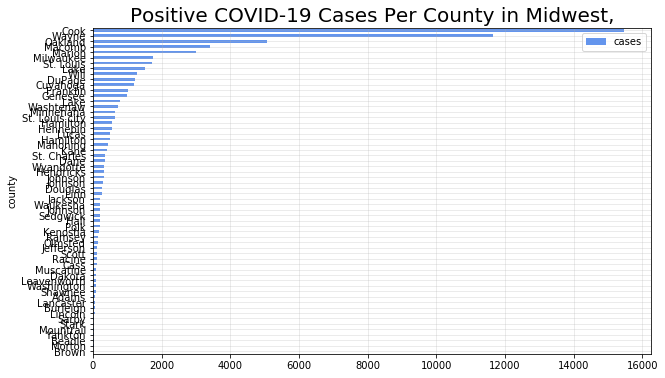

```python
# Plotting covid cases per county in Midwest

cases_chart = mw_census_covid_race_cases_df[["county", "cases"]]

# Drop NaN values
cases_chart = cases_chart.dropna()

# Set the index to be "County" so they will be used as labels
cases_chart = cases_chart.set_index("county").sort_values('cases')

# Use DataFrame.plot() to create a bar chart
cases_chart.plot(kind = "barh", color = "cornflowerblue", figsize = (10,6))

# Set a title for the chart
plt.title("Positive COVID-19 Cases Per County in Midwest,", fontsize = 20)
plt.grid(alpha = 0.3)
plt.show()
plt.tight_layout()
#plt.savefig("/Users/Tito/group_projects/my_project1_files/state_county_data_files/state_county_data_images/positive_cases_county_midwest.png")
```

# Top 10 Cases Per County DataFrame - All Midwest Counties

```python
# Top 10 cases - New DataFrame
top_10_cases = mw_census_covid_race_cases_df.head(10)
```

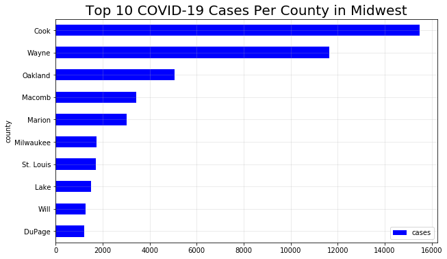

```python
# Plotting covid cases per county in Midwest

cases_chart = top_10_cases[["county", "cases"]]

# Drop NaN values
cases_chart = cases_chart.dropna()

# Set the index to be "County" so they will be used as labels
cases_chart = cases_chart.set_index("county").sort_values('cases')

# Use DataFrame.plot() to create a bar chart
cases_chart.plot(kind = "barh", color = "blue", figsize = (10,6))

# Set a title for the chart
plt.title("Top 10 COVID-19 Cases Per County in Midwest", fontsize = 20)
plt.grid(alpha = 0.3)
plt.show()
plt.tight_layout()
```

# Most COVID-19 Deaths By County (Midwest)

Unanswered question: What are the total number of deaths by Race per county? (Not enough data available)

```python
# Greatest number of covid deaths by all Midwest counties

# df.assign(total = df.bid1+df.bid2).sort_values(['itemX','total'],ascending=False).groupby('itemX').head(5)

mw_census_covid_race_deaths_df = mw_census_covid_df.sort_values(['deaths', 'White (%)', 'Black or African American (%)', 'American Indian and Alaska Native (%)', 'Asian (%)', 'Hawaiian and Other Pacific Islander (%)', 'Other (%)', 'Two or More Mixed (%)'], ascending = False).groupby('state').head(5)

mw_census_covid_race_deaths_df.head()
```

|  | state | county | fips | cases | deaths | Population | White | Black or African American | American Indian and Alaska Native | Asian | Hawaiian and Other Pacific Islander | Other | Two or More Mixed | White (%) | Black or African American (%) | American Indian and Alaska Native (%) | Asian (%) | Hawaiian and Other Pacific Islander (%) | Other (%) | Two or More Mixed (%) |
| --- | --- | --- | --- | --- | --- | --- | --- | --- | --- | --- | --- | --- | --- | --- | --- | --- | --- | --- | --- | --- |
| 398 | Michigan | Wayne | 26163.0 | 11648 | 760 | 1804507.0 | 954450.0 | 721705.0 | 6396.0 | 48823.0 | 279.0 | 31469.0 | 41385.0 | 0.528926 | 0.399946 | 0.003544 | 0.027056 | 0.000155 | 0.017439 | 0.022934 |
| 11 | Illinois | Cook | 17031.0 | 15474 | 543 | 5212372.0 | 2955886.0 | 1272312.0 | 12644.0 | 336055.0 | 1105.0 | 529889.0 | 104481.0 | 0.567090 | 0.244095 | 0.002426 | 0.064473 | 0.000212 | 0.101660 | 0.020045 |
| 380 | Michigan | Oakland | 26125.0 | 5073 | 347 | 1213406.0 | 936853.0 | 165652.0 | 3088.0 | 71143.0 | 267.0 | 7869.0 | 28534.0 | 0.772085 | 0.136518 | 0.002545 | 0.058631 | 0.000220 | 0.006485 | 0.023516 |
| 367 | Michigan | Macomb | 26099.0 | 3418 | 240 | 845197.0 | 715360.0 | 78952.0 | 2179.0 | 27423.0 | 222.0 | 4441.0 | 16620.0 | 0.846383 | 0.093413 | 0.002578 | 0.032446 | 0.000263 | 0.005254 | 0.019664 |
| 135 | Indiana | Marion | 18097.0 | 3012 | 123 | 912242.0 | 578316.0 | 244753.0 | 2295.0 | 19393.0 | 112.0 | 42414.0 | 24959.0 | 0.633950 | 0.268298 | 0.002516 | 0.021259 | 0.000123 | 0.046494 | 0.027360 |